# Anna-Pietryka

Anna Pietryka

7 01 2022

# Wstęp

Celem projektu jest porównanie działania metod służących do szacowania VaR oraz warunkowej wartości narażonej na ryzyko. Analiza zostanie przeprowadzona na podstawie notowań firm zarejestrowanych na polskiej, amerykańskiej i brytyjskiej giełdzie. Do badania zostaną wykorzystane notowania następujących firm:  
- CCC notowana na WIG 20  
- Accenture Plc notowana na SP&500  
- Aviva Plc notowana na UK100

W badaniu zostanie porównane działanie następujących technik:  
1. Metoda historyczna z wagami,  
2. Metoda o zmieniającej się zmienności w czasie z zastosowaniem EWMA,  
3. Metoda o zmieniającej się zmienności w czasie z zastosowaniem GARCH(1,1).

Jakość zastosowanych technik zostanie wyznaczona za pomocą:  
1.Testu Kupca,  
2.Testu wartości rzeczywistej.

# Wstępna analiza danych

Na wykresach poniżej zostały przestawione dzienne notowania oraz stopy zwrotu wybranych spółek.

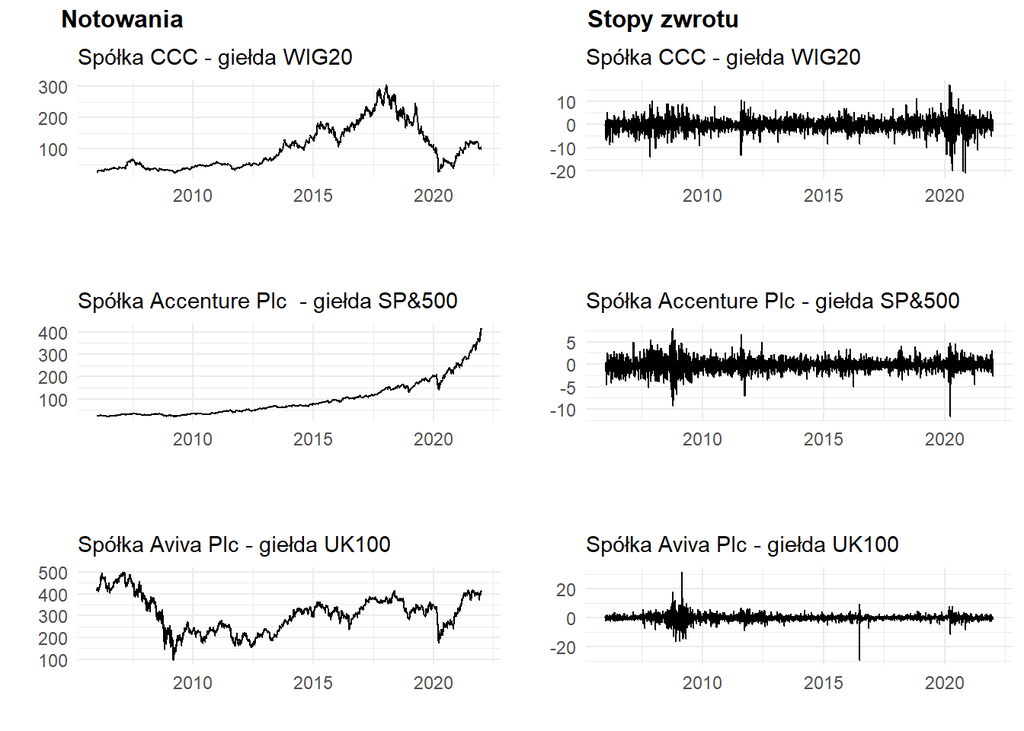

Na wykresach stóp zwrotu widać okresy większej i mniejszej zmienności, czyli efekt grupowania wariancji. Najlepiej widać to zjawisko dla akcji notowanych na giełdzie polskiej i amerykańskiej. Na wszystkich wykresach można zaobserwować okres dużej zmienności w latach 2008-2009. Jest to wynik kryzysu gospodarczego. Dla akcji notowanych na giełdzie brytyjskiej i amerykańskiej występują stosunkowo wysokie wahania około 2016 i 2020 roku. Dla spółki notowanej na giełdzie polskiej szczególnie duża zmienność nie wystęuje w 2016 roku, natomiast jest widoczna podczas kryzysu wywołanego epidemią w 2020 roku.

# Podstawowe statystki opisowe

## Spółka CCC - giełda WIG20

```
##             X..dane_pl.Stopa_zwrotu
## nobs                    3984.000000
## NAs                        0.000000
## Minimum                  -20.937500
## Maximum                   17.142857
## 1. Quartile               -1.196371
## 3. Quartile                1.296490
## Mean                       0.018023
## Median                     0.000000
## Sum                       71.804182
## SE Mean                    0.039684
## LCL Mean                  -0.059779
## UCL Mean                   0.095825
## Variance                   6.273990
## Stdev                      2.504793
## Skewness                  -0.438030
## Kurtosis                   7.373540
```

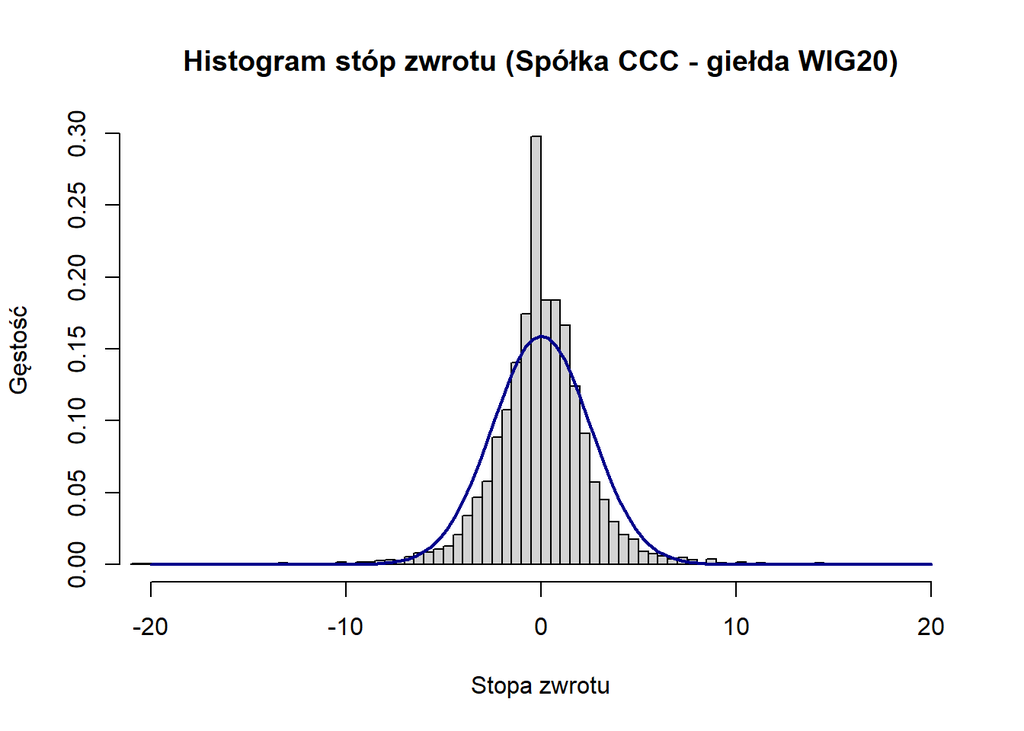

Wykres Q-Q obrazuje, że prawdopodobieństwo wystąpienia obserwacji oddalonych od średniej (nietypowych zmian) jest znacznie wyższe niż w rozkładzie normalnym.

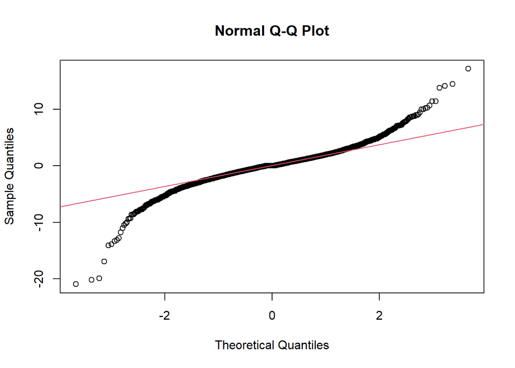

## Spółka Accenture Plc - giełda SP&500

```
##             X..dane_usa.Stopa_zwrotu
## nobs                     4027.000000
## NAs                         0.000000
## Minimum                   -11.695945
## Maximum                     7.974782
## 1. Quartile                -0.786491
## 3. Quartile                 0.543987
## Mean                       -0.114374
## Median                     -0.116056
## Sum                      -460.584102
## SE Mean                     0.020798
## LCL Mean                   -0.155149
## UCL Mean                   -0.073599
## Variance                    1.741863
## Stdev                       1.319797
## Skewness                   -0.158384
## Kurtosis                    5.060592
```

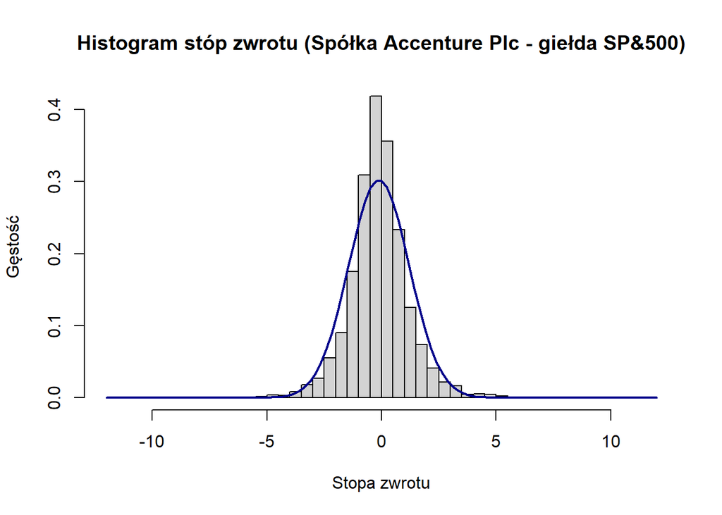

Wykres Q-Q obrazuje, że prawdopodobieństwo wystąpienia obserwacji oddalonych od średniej (nietypowych zmian) jest znacznie wyższe niż w rozkładzie normalnym.

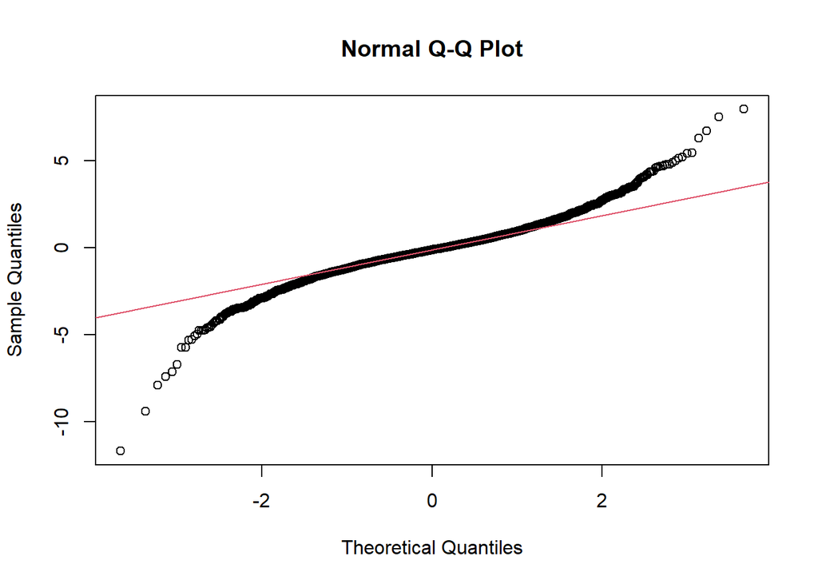

## Spółka Aviva Plc - giełda UK100

Stopy zwrotu dla firmy Aviva wahają się od -29,23% do 31,32%. Średnia stóp zwrotu jest nieznacznie niższa od mediany. Zależność ta wskazuje na lewostronną asymetrię rozkładu. Na wykresie gęstości można zaobserwować, że asymetria wyników jest niewielka. Kurtoza jest wyższa od 3, co oznacza, że rozkład jest leptokurtyczny.

```
##             X..dane_uk.Stopa_zwrotu
## nobs                    4035.000000
## NAs                        0.000000
## Minimum                  -29.236923
## Maximum                   31.323884
## 1. Quartile               -0.789642
## 3. Quartile                0.933258
## Mean                       0.086691
## Median                     0.091901
## Sum                      349.799599
## SE Mean                    0.033582
## LCL Mean                   0.020851
## UCL Mean                   0.152531
## Variance                   4.550561
## Stdev                      2.133204
## Skewness                  -0.056075
## Kurtosis                  28.649176
```

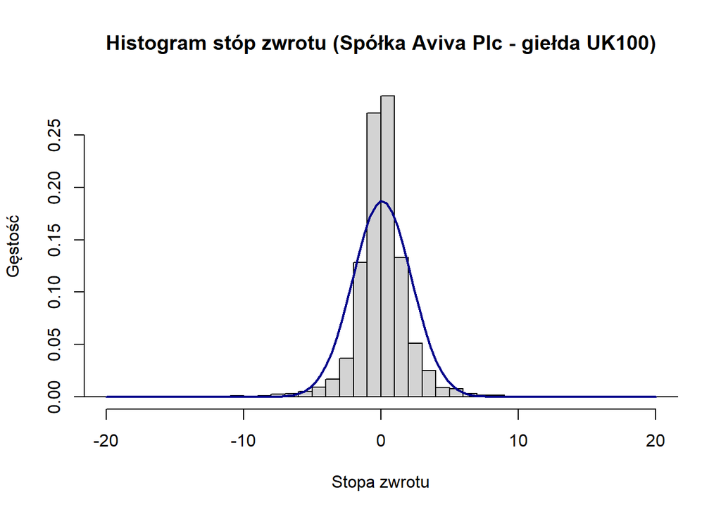

Wykres Q-Q obrazuje, że prawdopodobieństwo wystąpienia obserwacji oddalonych od średniej (nietypowych zmian) jest znacznie wyższe niż w rozkładzie normalnym.

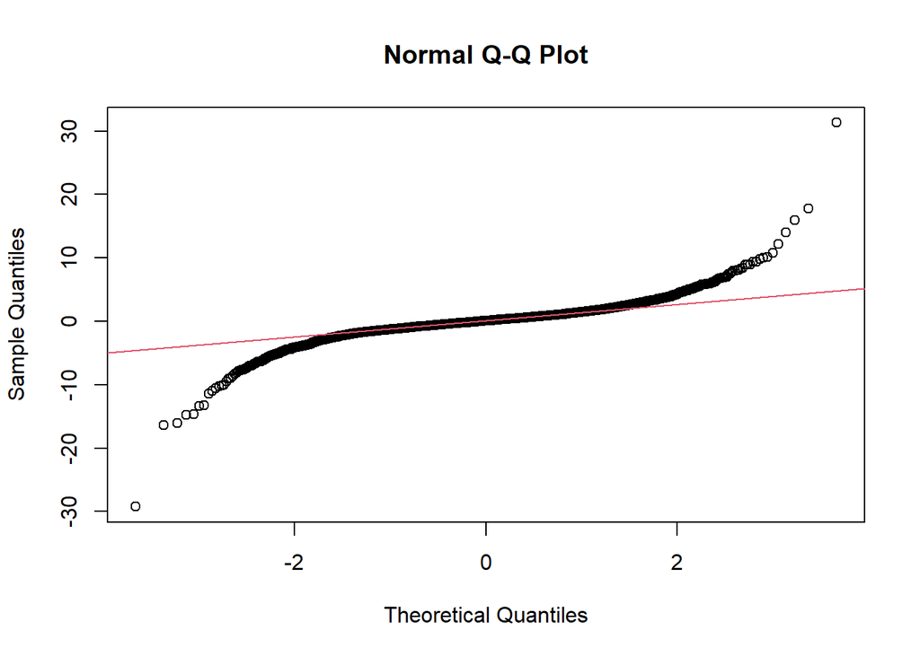

# Wyznaczanie VaR i ES

VaR (wartość narażona na ryzyko) jest to statystyczna miara ryzyka, która wyraża maksymalną stratę na portfelu inwestycyjnym z zadanym z góry prawdopodobieństwem i w ściśle określonym czasie. W projekcie wartość VaR została wyliczona na podstawie 250 dni, co odpowiada ilości dni giełdowych w roku. ES, czyli warunkowa wartość narażona na ryzyko, jest wartością oczekiwaną strat jeśli poziom VaR zostanie przekroczony. W projekcie zostanie oszacowany 95% i 99% VaR i ES za pomocą trzech wybranych metod.

Aby wartość VaR i ES były dodatnie stopy zwrotu zostały przemnożone przez -1. Stopy zwrotu takiej postaci będą wykorzystane do dalszych obliczeń.

## 1. Metoda historyczna z wagami

Metoda symulacji historycznej przyporządkowuje odpowiednie wagi obserwacją położonym bliżej lub dalej szacowanego punktu. Obserwacje położone bliżej szacownej wartości straty mają większy wpływ na wartość VaR niż obserwacje znajdujące się dalej. Jest to zgodne z intuicją, że większy wpływ na zmiany cen na rynku mają wydarzenia z wczoraj niż z przed kilku miesięcy.

Poniżej został przedstawiony sposób szacowania 99% wartości VaR i ES za pomocą metody historycznej z wagami dla spółki CCC notowanej na WIG20. Dla pozostałych przypadków metoda została zastosowana analogicznie.

```r
# 99% VaR i ES
# Giełda polska (WIG20) - Metoda historyczna z wagami

n = 250 # szerokość okna
q = 0.995 # iloraz q
w = seq(1,n,1) # wektor 1:250 do obliczenia prawdopodobieństwa
pi = (q^(n-w)*(1-q))/(1-q^n) # prawdopodobieństwo dla każdej obs. i


dane_pl$VaR_99_HW <- NA
dane_pl$ES_99_HW <- NA

# 99% VaR i ES
for (i in 1:(dim(dane_pl)[1]-n)){
    dane_fragment <- dane_pl[i:(i+n-1),] # 250 obs. historycznych
    dane_fragment$prawdopodobienstwo <- pi

    # Sortowanie według stóp zwrotu
    dane_fragment_posortowane <- dane_fragment %>% arrange(Stopa_zwrotu_znak)

    dane_fragment_posortowane$dystrybuanta <- NA

    # Sumowanie prawdopodobieństw
    for (j in 1:nrow(dane_fragment)){
      dane_fragment_posortowane[j,"dystrybuanta"] <-
      sum(dane_fragment_posortowane[1:j, "prawdopodobienstwo"])
    }

    # Wartość 99 kwantyla rozkładu - wartość 99% VaR
    kwantyl <- 0.99
    powyzej_kwantyla <- dane_fragment_posortowane %>%
      dplyr::filter(dane_fragment_posortowane$dystrybuanta >= kwantyl)
    VaR <- powyzej_kwantyla[1, "Stopa_zwrotu_znak"]
    dane_pl[(i+n), "VaR_99_HW"] <- VaR

    # ES
    ES <-  dane_fragment_posortowane %>% dplyr::filter(Stopa_zwrotu_znak > VaR)
    dane_pl[(i+n), "ES_99_HW"] <- mean(ES$Stopa_zwrotu_znak)
}
```

## Metoda o zmieniającej się zmienności w czasie (tj. EWMA)

Metoda uwzględniająca heteroskedastyczność stóp zwrotu zakłada, że każdy scenariusz może wydarzyć się z równym prawdopodobieństwem, a zmiana wysokości spodziewanej straty jest uaktualniania o stosunek zmienności z chwili t do zmienności wyliczanej za pomocą metody EWMA.

Poniżej został przedstawiony sposób szacowania 99% wartości VaR i ES za pomocą metody EWMA dla spółki CCC notowanej na WIG20. Dla pozostałych przypadków metoda została zastosowana analogicznie.

```r
# 99% VaR i ES
# Giełda polska (WIG20) - Metoda o zmieniającej się zmienności w czasie (tj. EWMA)
library(MTS) # pakiet zawierający funkcję EWMAvol()

dane_pl$ewma_94 <- NA
ewma_94 <- EWMAvol(dane_pl$Stopa_zwrotu_znak, lambda = 0.94)
dane_pl$ewma_94 <- sqrt(ewma_94$Sigma.t) # zmienność oszacowana EWMA


# Metoda o zmieniającej się zmienności w czasie (tj. EWMA)
n = 250 # szerokość okna

# 99% VaR i ES
dane_pl$VaR_99_ewma <- NA
dane_pl$ES_99_ewma <- NA

for (i in 1:(dim(dane_pl)[1]-n)){

  # szukana w scenariuszu i strata - Zi
  fragment_danych <- dane_pl[i:(i+n-1),]
  fragment_danych$zmiennosc_Zi <- NA

  for (j in 1:(nrow(fragment_danych)-1)){
    zaobs_strata <- fragment_danych[j, "Stopa_zwrotu_znak"]
    zmiennosc_t <- fragment_danych[j, "ewma_94"]
    zmiennosc_t1 <- fragment_danych[j+1, "ewma_94"]
    fragment_danych$zmiennosc_Zi[j] <- zaobs_strata * (zmiennosc_t1/zmiennosc_t)
  }
  fragment_danych <- fragment_danych[-nrow(fragment_danych),]

  # 99% Var
  VaR <- quantile(fragment_danych$zmiennosc_Zi, 0.99)
  dane_pl[(i+n), "VaR_99_ewma"]<- VaR

  # ES
  ES <-  fragment_danych %>% dplyr::filter(zmiennosc_Zi > VaR)
  dane_pl[(i+n), "ES_99_ewma"] <- mean(ES$zmiennosc_Zi)
}
```

## Metoda zmieniającej się zmienności w czasie (tj. GARCH(1,1))

W tym przypadku zmiana wysokości spodziewanej straty jest uaktualniania o stosunek zmienności z chwili t do zmienności wyliczanej za pomocą modelu GARCH(1,1).

```r
# 99% VaR i ES
# Giełda polska (WIG20) - Metoda o zmieniającej się zmienności w czasie (tj. GARCH(1,1))
library(fGarch)

garch11 <- garchFit(~ garch(1,1),
                    data = dane_pl$Stopa_zwrotu_znak,
                    trace = FALSE)


dane_pl$garch11 <- garch11@sigma.t # zmienność oszacowana GARCH(1,1)


# Metoda o zmieniającej się zmienności w czasie (tj. GARCH(1,1))
n = 250

dane_pl$VaR_99_garch11 <- NA
dane_pl$ES_99_garch11 <- NA


for (i in 1:(dim(dane_pl)[1]-n)){

  # szukana w scenariuszu i strata - Zi
  fragment_danych <- dane_pl[i:(i+n-1),]
  fragment_danych$zmiennosc_Zi <- NA

  for (j in 1:(nrow(fragment_danych)-1)){
    zaobs_strata <- fragment_danych[j, "Stopa_zwrotu_znak"]
    zmiennosc_t <- fragment_danych[j, "garch11"]
    zmiennosc_t1 <- fragment_danych[j+1, "garch11"]
    fragment_danych$zmiennosc_Zi[j] <- zaobs_strata * (zmiennosc_t1/zmiennosc_t)
  }
  fragment_danych <- fragment_danych[-nrow(fragment_danych),]

  # 99% Var
  VaR <- quantile(fragment_danych$zmiennosc_Zi, 0.99)
  dane_pl[(i+n), "VaR_99_garch11"]<- VaR

  # ES
  ES<-  fragment_danych %>% dplyr::filter(zmiennosc_Zi > VaR)
  dane_pl[(i+n), "ES_99_garch11"] <- mean(ES$zmiennosc_Zi)
}
```

# Porównanie wartości VaR szacownej wybranymi metodami

## Spółka CCC - WIG20

Wartości VaR szacowane metodami uwzględniającymi okresy zmienności stóp zwrotu przyjmują większe wartości od wartości VaR szacownych za pomocą Metody historycznej z wagami.

Na podstawie pasma VaR dla metody historycznej z wagami można zauważyć wzrosty wartości VaR następujące po pojedynczych, dużych wahaniach rzeczywistych stóp zwrotu. Jest to zgodne z założeniem, że obserwacje blisko szacowanego punktu zmienności przyjmują większą wagę.

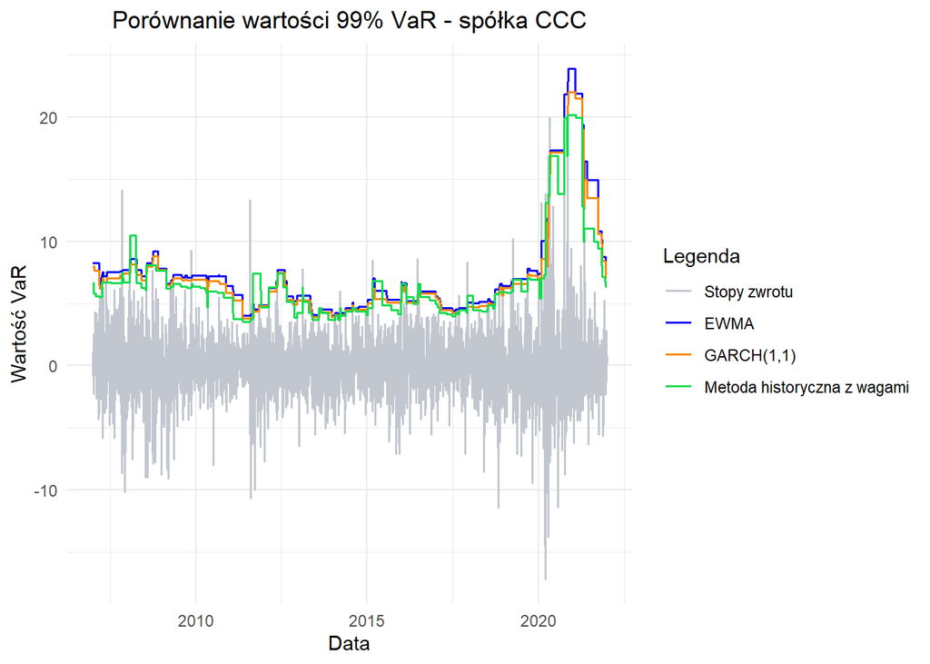

Dla 95% VaR nie widać już tak wyraźniej różnicy dla wybranych metod. Zdecydowanie częściej rzeczywiste stopy zwrotu przekraczają wartość 95% VaR. Dodatkowo analizowane pasmo VaR zmienia się bardziej dynamicznie od 99% VaR dla wszytskich badanych metod.

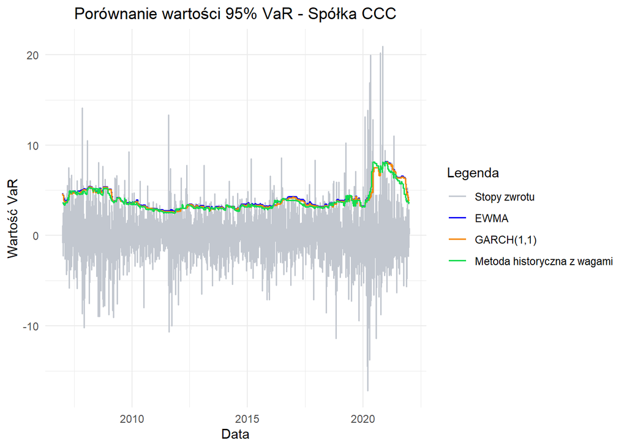

## Firma Accenture - S&P500

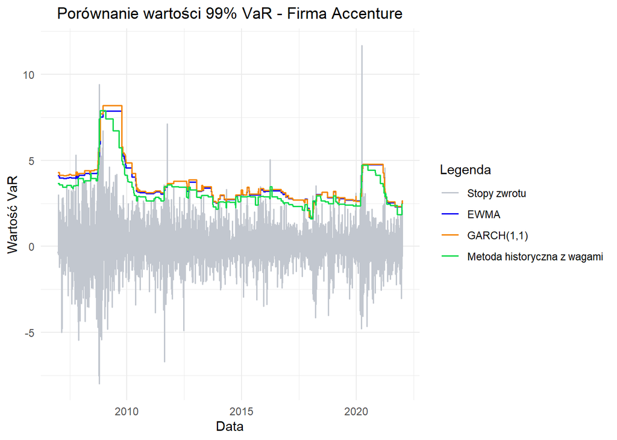

Dodatkowo na wykresach można zauważyć, że pasma VaR estymowane za pomocą metod uwzględniających heteroskedastyczność wariancji często pokrywają się. Oznacza to, że parametr omega, będący średnią ważoną długookresowej wariancji w modelu GARCH jest równy zero. Różnice pomiędzy pasmami dla których zmienność jest estymowana za pomocą EWMA i GARCH są bardziej widoczne dla 99% wartości VaR niż dla 95% wartości VaR. Czyli dla niższego poziomu ufności różnice pomiędzy szukanym poziomem straty są niewielkie, zwłaszcza dla okresów o mniejszej zmienności stóp.

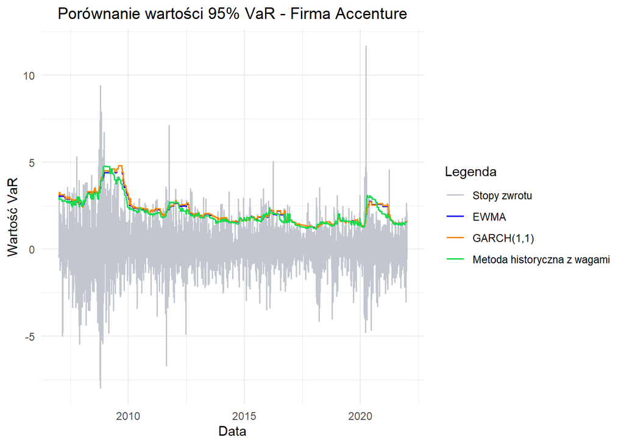

## Firma Aviva - UK100

Na wykresach porównujących pasma VaR dla firmy Aviva można zaobserwować zależności podobne do tych występujących dla firmy Accenture. Dla cen akcji firmy największa zmienność występowała w okresie pomiędzy 2008-2009. Można zauważyć, że po okresie dużej zmienności pasma VaR dla analizowanych metod jeszcze przez pewien okres czasu utrzymuje się na wysokim poziomie, co świadczy o dużym wpływie skoków na wzrost ryzyka.

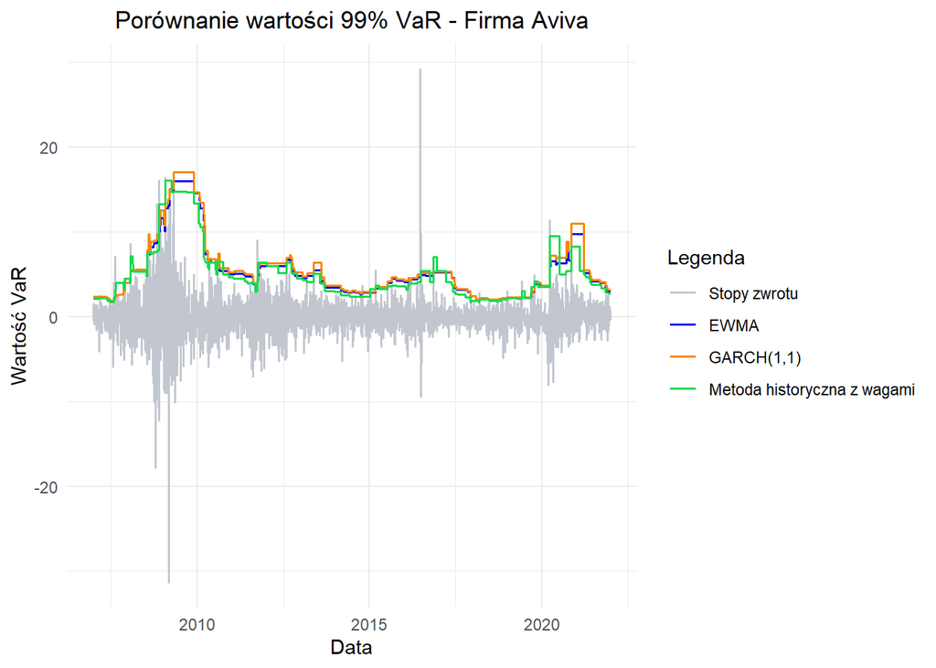

Na wykresie dla 95% wartości VaR nie widać już znacznych różnic pomiedzy pasami. Jedynym okresem, gdzie można dostrzec wyraźne różnice jest okres dużej zmienności występujący na początku analizowanego okresu. Pasmo szacowane za pomocą metody symulacji historycznej z wagami szybciej wraca do punktu równowagi niż pasma uwzględniające występowanie okresów zmienności.

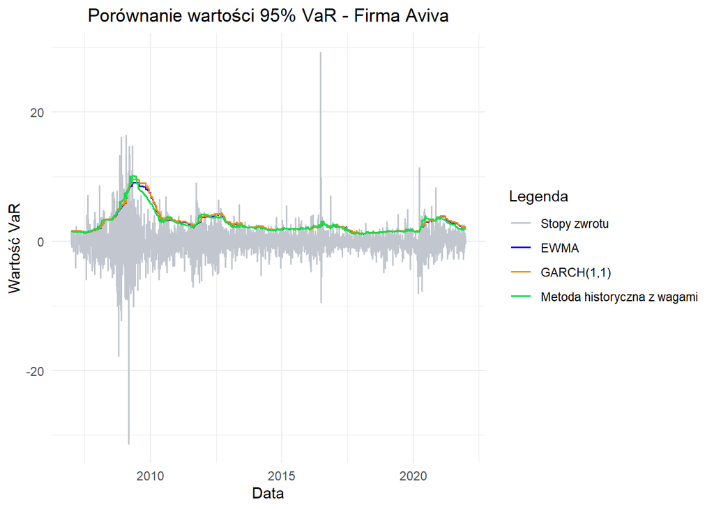

# Testy wsteczne

## Test Kupca

Test Kupca jest nieparametrycznym testem opierającym się na proporcji przekroczeń oszacowanej wartości VaR, w obrębie danego okna, przez rzeczywiste stopy zwrotu. Prawdopodobieństwo wystąpienia N przekroczeń w próbie T jest opisane za pomocą rozkładu dwumianowego. Hipoteza zerowa testu mówi o tym, że VaR został dobrze wyznaczony, czyli liczba przekroczeń w obrębie danego okna jest dopuszczalna. Liczba przekroczeń dla szerokości okna 250 dni i 99% poziomu ufności wynosi [0,7]. Natomiast dla 95% przedziału ufności wynosi [6,20]. Można zauważyć, że hipoteza zerowa w teście Kupca jest odrzucana zarówno dla przypadków, które niedoszacowująca lub przeszacowują wartość VaR.

Na listingu został przedstawiony schemat test Kupca.

```r
# SPÓŁKA CCC (WIG20)
# Test Kupca dla 99% VaR szcowanego metodą symulacji historycznych
library(GAS) # biblioteka dla testu BackVaRtest()

licznik_pl_kupiec_var99_MH = 0

n = 250 # szerokość okna
for(i in 250:(nrow(dane_pl)-1)){
  var <- rep(dane_pl[(i+1),"VaR_99_HW"],250)
  stopy <- dane_pl[(i-n+1):i,"Stopa_zwrotu_znak"]
  test <- BacktestVaR(stopy, var, 0.99)
  if(test$LRuc[2] > 0.05){
    licznik_pl_kupiec_var99_MH = licznik_pl_kupiec_var99_MH + 1
  }
}
```

## Test wartości rzeczywistej

Test wartości rzeczywistej polega na zmierzeniu rzeczywistej częstotliwości przekraczania przez wartości rzeczywiste oszacowanego poziomu VaR. W przypadku idealnie funkcjonującego modelu należałoby się spodziewać, że zrealizowana częstotliwość przekroczeń będzie równa poziomowi ufności z użyciem, którego dokonano oszacowania VaR.  
Na listingu poniżej został przedstawiony schemat testu wartości rzeczywistej.

```r
# SPÓŁKA CCC (WIG20)
# Test  wartości rzeczywistej dla 99% VaR szcowanego metodą symulacji historycznych

licznik_pl_twrz_var99_MH = 0

przekroczenia <- dane_pl[251:nrow(dane_pl),] %>% dplyr::filter(Stopa_zwrotu_znak > VaR_99_HW)
licznik_pl_twrz_var99_MH <- nrow(przekroczenia)


# Test  wartości rzeczywistej dla 95% VaR szcowanego metodą symulacji historycznych

licznik_pl_twrz_var95_MH = 0

przekroczenia <- dane_pl[251:nrow(dane_pl),] %>% dplyr::filter(Stopa_zwrotu_znak > VaR_95_HW)
licznik_pl_twrz_var95_MH <- nrow(przekroczenia)
```

# Wyniki testów

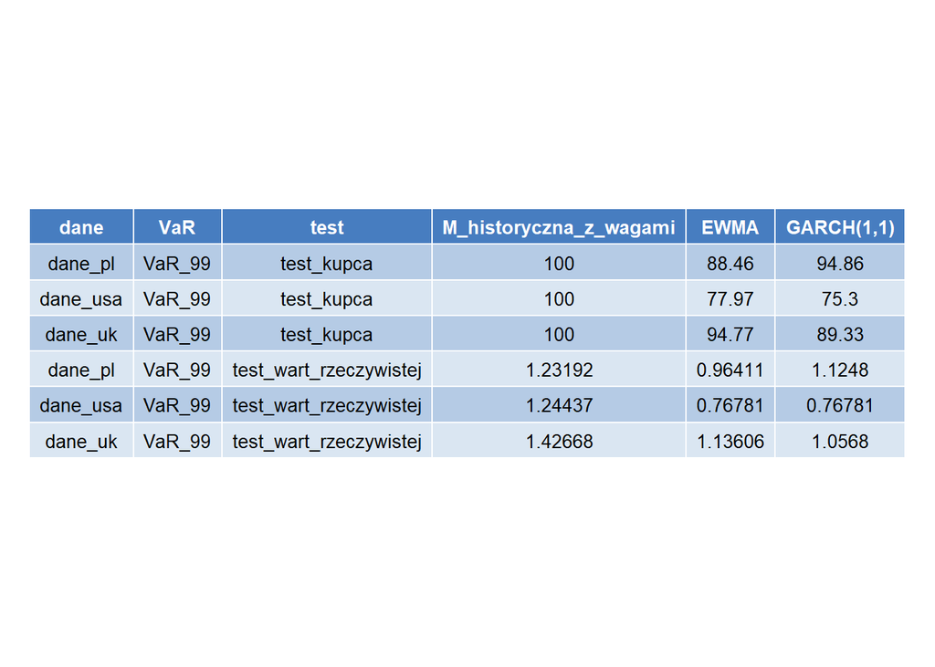

Test Kupca zwraca zbliżone wyniki dla metod wykorzystujących EWMA i modle GARCH. Test wartości rzeczywistej również wykazuje podobny poziom przekroczeń dla wspominanych technik. Warto również zauważyć, że wartości te są niższe o 5%.

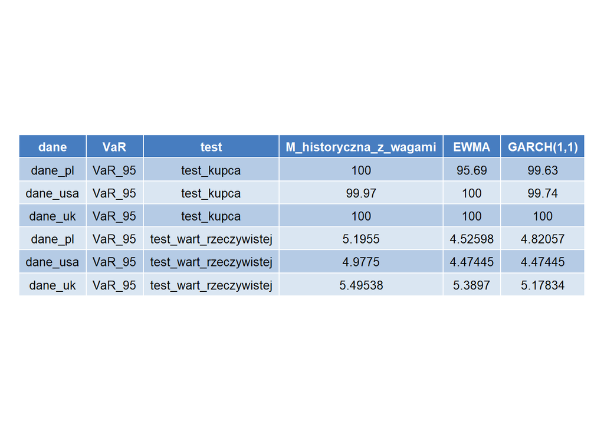

# Wnioski

- Test Kupca dla metody historycznej z wagami zwraca bardzo wysokie wyniki świadczące o poprawnie oszacowanej wartości VaR.
- Biorąc pod uwagę wyniki testu Kupca oraz położenie pasm VaR na wykresie można stwierdzić, że test Kupca w większości przypadków za wyjątki uznaje obserwacje znajdujące się poniżej wyznaczonego poziomu VaR.
- Na podstawie przeprowadzonej analizy można stwierdzić, że metoda historyczna z wagami szybciej dopasowuje się do zmian zachodzących na rynku. Natomiast metody wykorzystujące grupowanie zmienności szacują VaR bardziej zapobiegawczo i wykazują na wyższą wartość narażona na ryzyko.
- Wartości VaR po okresach kryzysu na rynku przez pewien okres utrzymują się na wysokim poziome. Najszybciej do poziomu równowagi wraca pasmo estymowane metodą historyczną z wagami ze względu na duży udział obserwacji znajdujących się blisko szacowanego punktu straty.